# Logistic Regression

STAT3612

2021/12/3

```r
#This sets working directory to source file directory.
setwd(dirname(rstudioapi::getActiveDocumentContext()$path))

IncomeData = read.csv("clean.csv")
IncomeData[sapply(IncomeData, is.character)] <- lapply(IncomeData[sapply(IncomeData, is.character)], as.factor)
head(IncomeData)
```

```
##   age fnlwgt education.num hours.per.week workclass marital.status
## 1  82 132870             9             18   Private          other
## 2  54 140359             4             40   Private          other
## 3  41 264663            10             40   Private          other
## 4  34 216864             9             45   Private          other
## 5  38 150601             6             40   Private          other
## 6  74  88638            16             20 State.gov    not-married
##          occupation  race    sex native.country            income
## 1   Exec.managerial White Female             US Less_or_equal_50K
## 2 Machine.op.inspct White Female             US Less_or_equal_50K
## 3    Prof.specialty White Female             US Less_or_equal_50K
## 4     Other.service White Female             US Less_or_equal_50K
## 5      Adm.clerical White   Male             US Less_or_equal_50K
## 6    Prof.specialty White Female             US     More_than_50K
##   net.capital.gain
## 1            -4356
## 2            -3900
## 3            -3900
## 4            -3770
## 5            -3770
## 6            -3683
```

# train test split

```r
library(caret)
set.seed(12L)

#training sample = 80%
train_size = floor(0.8 * nrow(IncomeData))
train_ind = sample(seq_len(nrow(IncomeData)), size = train_size)

train_set = IncomeData[train_ind,]
test_set = IncomeData[-train_ind,]

test_y = test_set$income
```

# Logistic Regression with glm

```r
start_time <- proc.time()
glm.model <- glm(formula = income~.,
                 data=train_set,
                 family = binomial(link = "logit"),
                 x = TRUE)
time.logistic <- proc.time() - start_time
time.logistic
```

```
## 用户 系统 流逝
## 1.84 0.07 1.91
```

```r
summary(glm.model)
```

```
##
## Call:
## glm(formula = income ~ ., family = binomial(link = "logit"),
##     data = train_set, x = TRUE)
##
## Deviance Residuals:
##     Min       1Q   Median       3Q      Max
## -4.4458  -0.5287  -0.2209  -0.0162   3.8029
##
## Coefficients:
##                               Estimate Std. Error z value Pr(>|z|)
## (Intercept)                 -6.676e+00  3.285e-01 -20.324  < 2e-16 ***
## age                          2.871e-02  1.801e-03  15.939  < 2e-16 ***
## fnlwgt                       7.150e-07  1.908e-07   3.747 0.000179 ***
## education.num                2.966e-01  1.054e-02  28.145  < 2e-16 ***
## hours.per.week               3.018e-02  1.855e-03  16.271  < 2e-16 ***
## workclassLocal.gov          -6.870e-01  1.225e-01  -5.608 2.05e-08 ***
## workclassPrivate            -4.465e-01  1.016e-01  -4.396 1.10e-05 ***
## workclassSelf.emp.inc       -3.032e-01  1.354e-01  -2.239 0.025129 *
## workclassSelf.emp.not.inc   -8.726e-01  1.193e-01  -7.311 2.65e-13 ***
## workclassState.gov          -7.563e-01  1.346e-01  -5.618 1.93e-08 ***
## workclassWithout.pay        -1.216e+01  1.259e+02  -0.097 0.923046
## marital.statusnot-married   -2.670e+00  7.006e-02 -38.115  < 2e-16 ***
## marital.statusother         -2.181e+00  6.574e-02 -33.182  < 2e-16 ***
## occupationArmed.Forces      -1.110e+01  2.164e+02  -0.051 0.959068
## occupationCraft.repair      -3.713e-02  8.702e-02  -0.427 0.669647
## occupationExec.managerial    7.887e-01  8.289e-02   9.515  < 2e-16 ***
## occupationFarming.fishing   -1.103e+00  1.527e-01  -7.222 5.13e-13 ***
## occupationHandlers.cleaners -7.255e-01  1.580e-01  -4.592 4.40e-06 ***
## occupationMachine.op.inspct -2.839e-01  1.104e-01  -2.572 0.010110 *
## occupationOther.service     -8.113e-01  1.267e-01  -6.401 1.54e-10 ***
## occupationPriv.house.serv   -3.625e+00  1.284e+00  -2.823 0.004754 **
## occupationProf.specialty     5.902e-01  8.630e-02   6.838 8.02e-12 ***
## occupationProtective.serv    5.294e-01  1.383e-01   3.829 0.000129 ***
## occupationSales              2.633e-01  8.927e-02   2.949 0.003183 **
## occupationTech.support       6.105e-01  1.197e-01   5.101 3.37e-07 ***
## occupationTransport.moving  -2.292e-01  1.092e-01  -2.099 0.035836 *
## raceAsian-Pac-Islander       6.223e-01  2.838e-01   2.192 0.028357 *
## raceBlack                    3.470e-01  2.662e-01   1.304 0.192389
## raceOther                   -2.342e-01  4.164e-01  -0.562 0.573804
## raceWhite                    5.068e-01  2.543e-01   1.993 0.046263 *
## sexMale                      1.758e-01  5.850e-02   3.005 0.002657 **
## native.countryUS             3.032e-01  8.800e-02   3.445 0.000571 ***
## net.capital.gain             2.390e-04  9.744e-06  24.522  < 2e-16 ***
## ---
## Signif. codes:  0 '***' 0.001 '**' 0.01 '*' 0.05 '.' 0.1 ' ' 1
##
## (Dispersion parameter for binomial family taken to be 1)
##
##     Null deviance: 27031  on 24128  degrees of freedom
## Residual deviance: 16291  on 24096  degrees of freedom
## AIC: 16357
##
## Number of Fisher Scoring iterations: 12
```

Check accuracy on test set; accuracy = 83.21%

```r
logit_prob = predict(glm.model, newdata= test_set,type = "response")
logit_pred = as.factor(ifelse(logit_prob > 0.5, "More_than_50K", "Less_or_equal_50K"))
confusionMatrix(logit_pred, test_y)
```

```
## Confusion Matrix and Statistics
##
##                    Reference
## Prediction          Less_or_equal_50K More_than_50K
##   Less_or_equal_50K              4145           649
##   More_than_50K                   364           875
##
##                Accuracy : 0.8321
##                  95% CI : (0.8224, 0.8414)
##     No Information Rate : 0.7474
##     P-Value [Acc > NIR] : < 2.2e-16
##
##                   Kappa : 0.526
##
##  Mcnemar's Test P-Value : < 2.2e-16
##
##             Sensitivity : 0.9193
##             Specificity : 0.5741
##          Pos Pred Value : 0.8646
##          Neg Pred Value : 0.7062
##              Prevalence : 0.7474
##          Detection Rate : 0.6871
##    Detection Prevalence : 0.7946
##       Balanced Accuracy : 0.7467
##
##        'Positive' Class : Less_or_equal_50K
##
```

# try adding second-order terms

```r
glm.model2 <- glm(formula = income~.^2,data=train_set, family = binomial(link = "logit"),x = TRUE)
summary(glm.model2)
```

```
##
## Call:
## glm(formula = income ~ .^2, family = binomial(link = "logit"),
##     data = train_set, x = TRUE)
##
## Deviance Residuals:
##     Min       1Q   Median       3Q      Max
## -3.5742  -0.5223  -0.1528   0.0000   3.7206
##
## Coefficients: (35 not defined because of singularities)
##                                                         Estimate Std. Error
## (Intercept)                                           -2.256e+01  7.695e+02
## age                                                    9.075e-03  5.114e-02
## fnlwgt                                                -3.685e-06  4.005e-06
## education.num                                          5.901e-01  2.209e-01
## hours.per.week                                         6.086e-02  4.082e-02
## workclassLocal.gov                                    -1.563e+00  2.033e+00
## workclassPrivate                                      -1.263e+00  1.887e+00
## workclassSelf.emp.inc                                  1.789e-01  2.881e+00
## workclassSelf.emp.not.inc                              4.261e+00  2.127e+00
## workclassState.gov                                     5.157e-01  2.242e+00
## workclassWithout.pay                                   1.110e+01  1.292e+05
## marital.statusnot-married                             -5.570e+00  1.416e+00
## marital.statusother                                   -2.738e+00  1.055e+00
## occupationArmed.Forces                                 2.003e-01  2.802e+04
## occupationCraft.repair                                -3.345e+00  1.860e+00
## occupationExec.managerial                             -3.137e+00  1.827e+00
## occupationFarming.fishing                             -1.796e+01  1.102e+03
## occupationHandlers.cleaners                           -1.358e+01  8.165e+02
## occupationMachine.op.inspct                           -1.639e+01  8.716e+02
## occupationOther.service                               -1.732e+01  6.086e+02
## occupationPriv.house.serv                             -1.265e+01  2.193e+03
## occupationProf.specialty                               1.181e+00  1.669e+00
## occupationProtective.serv                             -5.774e-01  2.503e+00
## occupationSales                                       -4.547e+00  1.986e+00
## occupationTech.support                                -1.757e+01  1.752e+03
## occupationTransport.moving                             2.560e-01  2.140e+00
## raceAsian-Pac-Islander                                 1.919e+01  7.695e+02
## raceBlack                                              1.583e+01  7.695e+02
## raceOther                                             -3.571e+01  1.360e+03
```

[output cut: 825 more lines]

```
## raceOther:net.capital.gain                              0.638 0.523794
## raceWhite:net.capital.gain                             -0.894 0.371424
## sexMale:native.countryUS                               -0.247 0.805272
## sexMale:net.capital.gain                                0.125 0.900533
## native.countryUS:net.capital.gain                       0.520 0.603200
## ---
## Signif. codes:  0 '***' 0.001 '**' 0.01 '*' 0.05 '.' 0.1 ' ' 1
##
## (Dispersion parameter for binomial family taken to be 1)
##
##     Null deviance: 27031  on 24128  degrees of freedom
## Residual deviance: 15394  on 23735  degrees of freedom
## AIC: 16182
##
## Number of Fisher Scoring iterations: 16
```

Test accuracy = 83.52%. The addition of second order terms only increase test accuracy by a insignificant 0.31%. Hence we will not add second order terms.

```r
logit_prob2 = predict(glm.model2, newdata= test_set,type = "response")
logit_pred2 = as.factor(ifelse(logit_prob2 > 0.5, "More_than_50K", "Less_or_equal_50K"))
confusionMatrix(logit_pred2, test_y)
```

```
## Confusion Matrix and Statistics
##
##                    Reference
## Prediction          Less_or_equal_50K More_than_50K
##   Less_or_equal_50K              4119           604
##   More_than_50K                   390           920
##
##                Accuracy : 0.8352
##                  95% CI : (0.8256, 0.8445)
##     No Information Rate : 0.7474
##     P-Value [Acc > NIR] : < 2.2e-16
##
##                   Kappa : 0.5424
##
##  Mcnemar's Test P-Value : 1.419e-11
##
##             Sensitivity : 0.9135
##             Specificity : 0.6037
##          Pos Pred Value : 0.8721
##          Neg Pred Value : 0.7023
##              Prevalence : 0.7474
##          Detection Rate : 0.6827
##    Detection Prevalence : 0.7829
##       Balanced Accuracy : 0.7586
##
##        'Positive' Class : Less_or_equal_50K
##
```

# Perform ANOVA Likelihood ratio test.

```r
anova(glm.model, test="LRT")
```

```
## Analysis of Deviance Table
##
## Model: binomial, link: logit
##
## Response: income
##
## Terms added sequentially (first to last)
##
##
##                  Df Deviance Resid. Df Resid. Dev  Pr(>Chi)
## NULL                             24128      27031
## age               1   1425.0     24127      25606 < 2.2e-16 ***
## fnlwgt            1      2.3     24126      25603 0.1323330
## education.num     1   2975.1     24125      22628 < 2.2e-16 ***
## hours.per.week    1    817.4     24124      21811 < 2.2e-16 ***
## workclass         6    136.4     24118      21674 < 2.2e-16 ***
## marital.status    2   3705.8     24116      17969 < 2.2e-16 ***
## occupation       13    589.8     24103      17379 < 2.2e-16 ***
## race              4     14.8     24099      17364 0.0050515 **
## sex               1     13.3     24098      17351 0.0002677 ***
## native.country    1     12.2     24097      17339 0.0004785 ***
## net.capital.gain  1   1048.0     24096      16291 < 2.2e-16 ***
## ---
## Signif. codes:  0 '***' 0.001 '**' 0.01 '*' 0.05 '.' 0.1 ' ' 1
```

Observe that fnlwgt is insignificant. Try removing it:

```r
glm.model3 <- glm(formula = income~. -fnlwgt,
                 data=train_set,
                 family = binomial(link = "logit"),
                 x = TRUE)
summary(glm.model3)
```

```
##
## Call:
## glm(formula = income ~ . - fnlwgt, family = binomial(link = "logit"),
##     data = train_set, x = TRUE)
##
## Deviance Residuals:
##     Min       1Q   Median       3Q      Max
## -4.4251  -0.5301  -0.2215  -0.0159   3.7872
##
## Coefficients:
##                               Estimate Std. Error z value Pr(>|z|)
## (Intercept)                 -6.541e+00  3.261e-01 -20.058  < 2e-16 ***
## age                          2.828e-02  1.796e-03  15.743  < 2e-16 ***
## education.num                2.963e-01  1.054e-02  28.114  < 2e-16 ***
## hours.per.week               3.001e-02  1.854e-03  16.189  < 2e-16 ***
## workclassLocal.gov          -6.794e-01  1.223e-01  -5.554 2.79e-08 ***
## workclassPrivate            -4.397e-01  1.014e-01  -4.336 1.45e-05 ***
## workclassSelf.emp.inc       -3.032e-01  1.352e-01  -2.243 0.024896 *
## workclassSelf.emp.not.inc   -8.693e-01  1.192e-01  -7.292 3.05e-13 ***
## workclassState.gov          -7.517e-01  1.345e-01  -5.589 2.28e-08 ***
## workclassWithout.pay        -1.216e+01  1.259e+02  -0.097 0.923082
## marital.statusnot-married   -2.665e+00  6.999e-02 -38.079  < 2e-16 ***
## marital.statusother         -2.175e+00  6.567e-02 -33.125  < 2e-16 ***
## occupationArmed.Forces      -1.110e+01  2.165e+02  -0.051 0.959091
## occupationCraft.repair      -4.139e-02  8.698e-02  -0.476 0.634164
## occupationExec.managerial    7.846e-01  8.285e-02   9.471  < 2e-16 ***
## occupationFarming.fishing   -1.126e+00  1.527e-01  -7.375 1.64e-13 ***
## occupationHandlers.cleaners -7.284e-01  1.581e-01  -4.609 4.05e-06 ***
## occupationMachine.op.inspct -2.854e-01  1.103e-01  -2.586 0.009701 **
## occupationOther.service     -8.226e-01  1.267e-01  -6.493 8.40e-11 ***
## occupationPriv.house.serv   -3.689e+00  1.290e+00  -2.860 0.004237 **
## occupationProf.specialty     5.878e-01  8.623e-02   6.816 9.35e-12 ***
## occupationProtective.serv    5.302e-01  1.382e-01   3.838 0.000124 ***
## occupationSales              2.598e-01  8.921e-02   2.912 0.003590 **
## occupationTech.support       6.076e-01  1.196e-01   5.079 3.79e-07 ***
## occupationTransport.moving  -2.319e-01  1.091e-01  -2.124 0.033633 *
## raceAsian-Pac-Islander       6.306e-01  2.836e-01   2.224 0.026168 *
## raceBlack                    4.242e-01  2.651e-01   1.600 0.109594
## raceOther                   -2.005e-01  4.166e-01  -0.481 0.630352
## raceWhite                    5.461e-01  2.539e-01   2.151 0.031484 *
## sexMale                      1.851e-01  5.842e-02   3.169 0.001531 **
## native.countryUS             2.764e-01  8.773e-02   3.151 0.001629 **
## net.capital.gain             2.394e-04  9.750e-06  24.552  < 2e-16 ***
## ---
## Signif. codes:  0 '***' 0.001 '**' 0.01 '*' 0.05 '.' 0.1 ' ' 1
##
## (Dispersion parameter for binomial family taken to be 1)
##
##     Null deviance: 27031  on 24128  degrees of freedom
## Residual deviance: 16305  on 24097  degrees of freedom
## AIC: 16369
##
## Number of Fisher Scoring iterations: 12
```

Test accuracy = 83.14%. Removing fnlwgt only decrease accuracy. Furthermore, this variable is hard to interpret. Hence, we remove it.

```r
logit_prob3 = predict(glm.model3, newdata= test_set,type = "response")
logit_pred3 = as.factor(ifelse(logit_prob3 > 0.5, "More_than_50K", "Less_or_equal_50K"))
confusionMatrix(logit_pred3, test_y)
```

```
## Confusion Matrix and Statistics
##
##                    Reference
## Prediction          Less_or_equal_50K More_than_50K
##   Less_or_equal_50K              4142           650
##   More_than_50K                   367           874
##
##                Accuracy : 0.8314
##                  95% CI : (0.8217, 0.8408)
##     No Information Rate : 0.7474
##     P-Value [Acc > NIR] : < 2.2e-16
##
##                   Kappa : 0.5243
##
##  Mcnemar's Test P-Value : < 2.2e-16
##
##             Sensitivity : 0.9186
##             Specificity : 0.5735
##          Pos Pred Value : 0.8644
##          Neg Pred Value : 0.7043
##              Prevalence : 0.7474
##          Detection Rate : 0.6866
##    Detection Prevalence : 0.7943
##       Balanced Accuracy : 0.7460
##
##        'Positive' Class : Less_or_equal_50K
##
```

```r
IncomeData$fnlwgt = NULL
```

# Assumption Checking

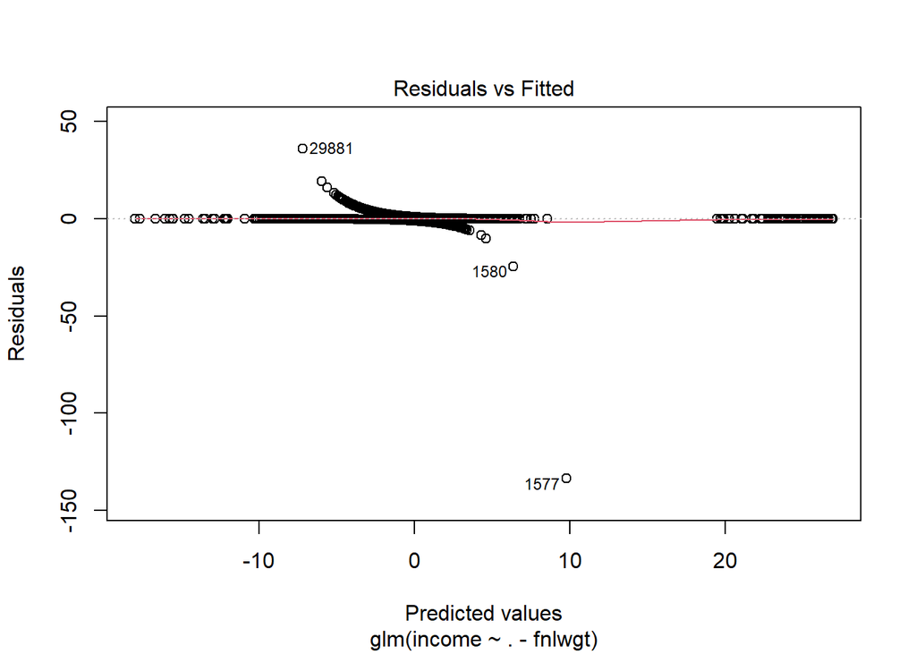

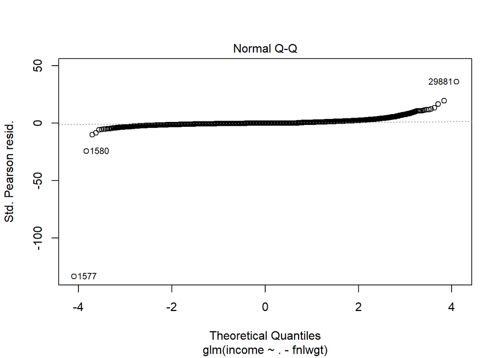

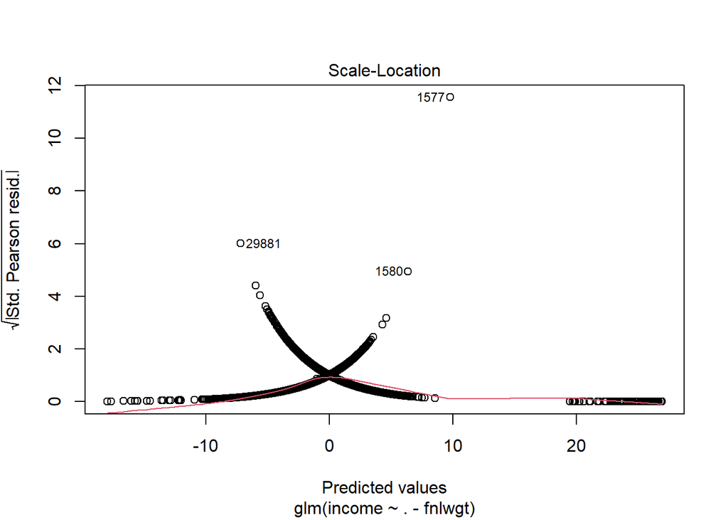

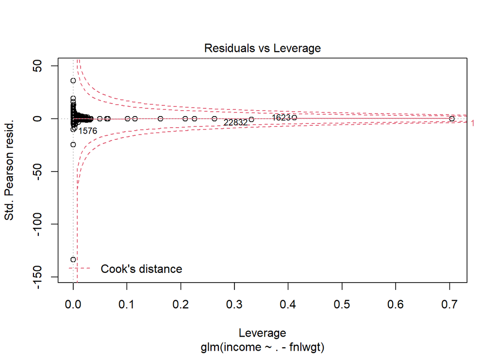

```r
plot(glm.model3)
```

# Futher tuning by grouping variables.

### Check large residuals:

We first observe patterns for the 15 largest residuals

```r
r <- residuals(glm.model3)
temp = abs(r)
temp = order(temp,decreasing = TRUE)
IncomeData[temp[1:15],]
```

```
##       age education.num hours.per.week        workclass marital.status
## 19856  38            13             45        Local.gov        married
## 22560  64             6             40          Private        married
## 3013   37            13             45        Local.gov    not-married
## 21903  23             9             30          Private    not-married
## 14686  47            13             40 Self.emp.not.inc        married
## 3755   38            13             45          Private    not-married
## 15585  34            10             40        State.gov        married
## 10648  48             9             28          Private    not-married
## 23035  47             7             40          Private          other
## 1697   37            13             40          Private        married
## 2882   37            10             40        Local.gov        married
## 18180  40             9             60          Private          other
## 12802  19             4             40          Private    not-married
## 1051   26             1             40          Private          other
```

[output cut: 33 more lines]

Using this intuition, we try grouping education.num and age.

GROUP EDUCATION.NUm

```r
train_set$cutEducation = cut(train_set$education.num, seq(-1,17,2))
test_set$cutEducation = cut(test_set$education.num, seq(-1,17,2))
```

```r
glm.model4 <- glm(formula = income~. -fnlwgt -education.num,
                 data=train_set,
                 family = binomial(link = "logit"),
                 x = TRUE)
summary(glm.model4)
```

```
##
## Call:
## glm(formula = income ~ . - fnlwgt - education.num, family = binomial(link = "logit"),
##     data = train_set, x = TRUE)
##
## Deviance Residuals:
##     Min       1Q   Median       3Q      Max
## -4.5160  -0.5294  -0.2226  -0.0023   3.6473
##
## Coefficients:
##                               Estimate Std. Error z value Pr(>|z|)
## (Intercept)                 -2.128e+01  1.164e+02  -0.183 0.854938
## age                          2.732e-02  1.813e-03  15.066  < 2e-16 ***
## hours.per.week               2.964e-02  1.854e-03  15.991  < 2e-16 ***
## workclassLocal.gov          -6.913e-01  1.229e-01  -5.623 1.88e-08 ***
## workclassPrivate            -4.318e-01  1.017e-01  -4.245 2.19e-05 ***
## workclassSelf.emp.inc       -2.990e-01  1.353e-01  -2.210 0.027114 *
## workclassSelf.emp.not.inc   -8.605e-01  1.194e-01  -7.205 5.79e-13 ***
## workclassState.gov          -7.650e-01  1.352e-01  -5.657 1.54e-08 ***
## workclassWithout.pay        -1.319e+01  2.082e+02  -0.063 0.949468
## marital.statusnot-married   -2.673e+00  7.042e-02 -37.949  < 2e-16 ***
## marital.statusother         -2.185e+00  6.589e-02 -33.164  < 2e-16 ***
## occupationArmed.Forces      -1.227e+01  3.500e+02  -0.035 0.972027
## occupationCraft.repair      -4.822e-02  8.708e-02  -0.554 0.579754
## occupationExec.managerial    7.939e-01  8.303e-02   9.561  < 2e-16 ***
## occupationFarming.fishing   -1.100e+00  1.521e-01  -7.228 4.89e-13 ***
## occupationHandlers.cleaners -7.477e-01  1.581e-01  -4.731 2.24e-06 ***
## occupationMachine.op.inspct -2.999e-01  1.106e-01  -2.710 0.006726 **
## occupationOther.service     -8.244e-01  1.267e-01  -6.506 7.74e-11 ***
## occupationPriv.house.serv   -3.634e+00  1.291e+00  -2.815 0.004872 **
## occupationProf.specialty     5.909e-01  8.771e-02   6.737 1.62e-11 ***
## occupationProtective.serv    5.370e-01  1.381e-01   3.888 0.000101 ***
## occupationSales              2.664e-01  8.921e-02   2.986 0.002827 **
## occupationTech.support       6.290e-01  1.200e-01   5.244 1.57e-07 ***
## occupationTransport.moving  -2.485e-01  1.094e-01  -2.272 0.023070 *
## raceAsian-Pac-Islander       6.724e-01  2.842e-01   2.366 0.017964 *
## raceBlack                    4.390e-01  2.657e-01   1.652 0.098522 .
## raceOther                   -2.051e-01  4.169e-01  -0.492 0.622787
## raceWhite                    5.637e-01  2.545e-01   2.215 0.026764 *
## sexMale                      1.925e-01  5.854e-02   3.288 0.001007 **
## native.countryUS             2.981e-01  8.843e-02   3.371 0.000748 ***
## net.capital.gain             2.443e-04  9.858e-06  24.778  < 2e-16 ***
## cutEducation(1,3]            1.620e+01  1.164e+02   0.139 0.889317
## cutEducation(3,5]            1.605e+01  1.164e+02   0.138 0.890352
## cutEducation(5,7]            1.672e+01  1.164e+02   0.144 0.885798
## cutEducation(7,9]            1.741e+01  1.164e+02   0.150 0.881121
## cutEducation(9,11]           1.777e+01  1.164e+02   0.153 0.878650
## cutEducation(11,13]          1.848e+01  1.164e+02   0.159 0.873877
## cutEducation(13,15]          1.909e+01  1.164e+02   0.164 0.869725
## cutEducation(15,17]          1.965e+01  1.164e+02   0.169 0.865968
## ---
## Signif. codes:  0 '***' 0.001 '**' 0.01 '*' 0.05 '.' 0.1 ' ' 1
##
## (Dispersion parameter for binomial family taken to be 1)
##
##     Null deviance: 27031  on 24128  degrees of freedom
## Residual deviance: 16314  on 24090  degrees of freedom
## AIC: 16392
##
## Number of Fisher Scoring iterations: 13
```

Observe that all the coefficients are similar and highly insignificant. This suggests that using the continuous education.num is better. Hence, we do not group education.num. Moreover, test accuracy decreased, but interpretability does not seem to increase.

```r
logit_prob4 = predict(glm.model4, newdata= test_set,type = "response")
logit_pred4 = as.factor(ifelse(logit_prob4 > 0.5, "More_than_50K", "Less_or_equal_50K"))
confusionMatrix(logit_pred4, test_y)
```

```
## Confusion Matrix and Statistics
##
##                    Reference
## Prediction          Less_or_equal_50K More_than_50K
##   Less_or_equal_50K              4143           654
##   More_than_50K                   366           870
##
##                Accuracy : 0.8309
##                  95% CI : (0.8212, 0.8403)
##     No Information Rate : 0.7474
##     P-Value [Acc > NIR] : < 2.2e-16
##
##                   Kappa : 0.5224
##
##  Mcnemar's Test P-Value : < 2.2e-16
##
##             Sensitivity : 0.9188
##             Specificity : 0.5709
##          Pos Pred Value : 0.8637
##          Neg Pred Value : 0.7039
##              Prevalence : 0.7474
##          Detection Rate : 0.6867
##    Detection Prevalence : 0.7951
##       Balanced Accuracy : 0.7448
##
##        'Positive' Class : Less_or_equal_50K
##
```

We now try grouping age.

```r
train_set$cutAge = cut(train_set$age, seq(16,90,10))
test_set$cutAge = cut(test_set$age, seq(16,90,10))
```

```r
glm.model5 <- glm(formula = income~. -fnlwgt -education.num -cutEducation - age,
                 data=train_set,
                 family = binomial(link = "logit"),
                 x = TRUE)
summary(glm.model5)
```

```
##
## Call:
## glm(formula = income ~ . - fnlwgt - education.num - cutEducation -
##     age, family = binomial(link = "logit"), data = train_set,
##     x = TRUE)
##
## Deviance Residuals:
##     Min       1Q   Median       3Q      Max
## -4.0162  -0.5674  -0.2228  -0.0280   3.5180
##
## Coefficients:
##                               Estimate Std. Error z value Pr(>|z|)
## (Intercept)                 -4.366e+00  3.158e-01 -13.826  < 2e-16 ***
## hours.per.week               2.739e-02  1.866e-03  14.679  < 2e-16 ***
## workclassLocal.gov          -6.147e-01  1.205e-01  -5.102 3.36e-07 ***
## workclassPrivate            -4.586e-01  1.002e-01  -4.578 4.69e-06 ***
## workclassSelf.emp.inc       -2.533e-01  1.331e-01  -1.904 0.056925 .
## workclassSelf.emp.not.inc   -8.375e-01  1.174e-01  -7.135 9.70e-13 ***
## workclassState.gov          -6.271e-01  1.319e-01  -4.754 2.00e-06 ***
## workclassWithout.pay        -1.169e+01  1.280e+02  -0.091 0.927248
## marital.statusnot-married   -2.272e+00  6.932e-02 -32.770  < 2e-16 ***
## marital.statusother         -2.164e+00  6.426e-02 -33.684  < 2e-16 ***
## occupationArmed.Forces      -1.134e+01  2.021e+02  -0.056 0.955243
## occupationCraft.repair      -3.680e-01  8.566e-02  -4.296 1.74e-05 ***
## occupationExec.managerial    1.052e+00  8.131e-02  12.940  < 2e-16 ***
## occupationFarming.fishing   -1.338e+00  1.489e-01  -8.980  < 2e-16 ***
## occupationHandlers.cleaners -1.134e+00  1.561e-01  -7.265 3.74e-13 ***
## occupationMachine.op.inspct -7.141e-01  1.082e-01  -6.597 4.19e-11 ***
## occupationOther.service     -1.097e+00  1.252e-01  -8.759  < 2e-16 ***
## occupationPriv.house.serv   -3.176e+00  1.234e+00  -2.573 0.010092 *
## occupationProf.specialty     1.294e+00  8.172e-02  15.839  < 2e-16 ***
## occupationProtective.serv    4.755e-01  1.372e-01   3.466 0.000528 ***
## occupationSales              4.031e-01  8.819e-02   4.572 4.84e-06 ***
## occupationTech.support       7.658e-01  1.194e-01   6.415 1.41e-10 ***
## occupationTransport.moving  -6.408e-01  1.069e-01  -5.994 2.04e-09 ***
## raceAsian-Pac-Islander       1.181e+00  2.855e-01   4.136 3.54e-05 ***
## raceBlack                    6.021e-01  2.692e-01   2.236 0.025332 *
## raceOther                   -4.554e-02  4.147e-01  -0.110 0.912557
## raceWhite                    8.308e-01  2.585e-01   3.214 0.001309 **
## sexMale                      2.745e-01  5.771e-02   4.757 1.96e-06 ***
## native.countryUS             4.049e-01  8.334e-02   4.858 1.19e-06 ***
## net.capital.gain             2.416e-04  9.539e-06  25.326  < 2e-16 ***
## cutAge(26,36]                1.404e+00  1.045e-01  13.435  < 2e-16 ***
## cutAge(36,46]                1.998e+00  1.048e-01  19.068  < 2e-16 ***
## cutAge(46,56]                2.138e+00  1.080e-01  19.802  < 2e-16 ***
## cutAge(56,66]                1.747e+00  1.174e-01  14.879  < 2e-16 ***
## cutAge(66,76]                1.249e+00  1.797e-01   6.951 3.62e-12 ***
## cutAge(76,86]                1.568e+00  3.729e-01   4.206 2.60e-05 ***
## ---
## Signif. codes:  0 '***' 0.001 '**' 0.01 '*' 0.05 '.' 0.1 ' ' 1
##
## (Dispersion parameter for binomial family taken to be 1)
##
##     Null deviance: 27000  on 24097  degrees of freedom
## Residual deviance: 16727  on 24062  degrees of freedom
##   (因为不存在，31个观察量被删除了)
## AIC: 16799
##
## Number of Fisher Scoring iterations: 12
```

```r
logit_prob5 = predict(glm.model5, newdata= test_set,type = "response")
logit_pred5 = as.factor(ifelse(logit_prob5 > 0.5, "More_than_50K", "Less_or_equal_50K"))
confusionMatrix(logit_pred5, test_y)
```

```
## Confusion Matrix and Statistics
##
##                    Reference
## Prediction          Less_or_equal_50K More_than_50K
##   Less_or_equal_50K              4111           641
##   More_than_50K                   392           882
##
##                Accuracy : 0.8286
##                  95% CI : (0.8188, 0.838)
##     No Information Rate : 0.7473
##     P-Value [Acc > NIR] : < 2.2e-16
##
##                   Kappa : 0.5202
##
##  Mcnemar's Test P-Value : 1.199e-14
##
##             Sensitivity : 0.9129
##             Specificity : 0.5791
##          Pos Pred Value : 0.8651
##          Neg Pred Value : 0.6923
##              Prevalence : 0.7473
##          Detection Rate : 0.6822
##    Detection Prevalence : 0.7886
##       Balanced Accuracy : 0.7460
##
##        'Positive' Class : Less_or_equal_50K
##
```

Observe that test accuracy decreased slightly, but interpretability does not seem to increase. So we do not group age.